# Indexação simples de vetores e dataframes

Daniel Maurenza de Oliveira

https://github.com/dmaurenza/Curso-Intermediario-R

Nesta aula veremos um dos conceitos mais importante para o usuário de R, a Indexação. Estuderemos seus objetivos e os comandos de indexações, seja em vatores ou dataframes

# Elementos da Aula

1. Indexação de Vetores
2. Indexação de Dataframes

## Indexação de Vetores

Indexação é a ação de extrair um elemento específico, ou um conjunto de elementos, de um objeto. Podemos extrair sub-conjuntos específicos de dados de acordo com as ‘coordenadas’ dos dados que buscamos, assim como em um jogo de batalha naval. Utilizaremos três tipos de operadores para realizar a indexação:

[] extrai um ou mais elementos em vetores, listas, ou data.frame;

[[]] extrai um ou mais elementos em listas ou data.frame;

$ extrai elementos pelo nome em listas e data.frame.

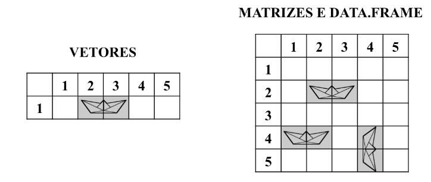

Para exemplificarmos um vetor, vamos aprender a função “seq()”

```r
vetor1 <- seq(from = 1, to = 100)

vetor1
```

```
##   [1]   1   2   3   4   5   6   7   8   9  10  11  12  13  14  15  16  17  18
##  [19]  19  20  21  22  23  24  25  26  27  28  29  30  31  32  33  34  35  36
##  [37]  37  38  39  40  41  42  43  44  45  46  47  48  49  50  51  52  53  54
##  [55]  55  56  57  58  59  60  61  62  63  64  65  66  67  68  69  70  71  72
##  [73]  73  74  75  76  77  78  79  80  81  82  83  84  85  86  87  88  89  90
##  [91]  91  92  93  94  95  96  97  98  99 100
```

```r
# podemos definir o incremento, utilizando a função by

vetor2 <- seq(from = 1, to = 100, by = 2)

vetor2
```

```
##  [1]  1  3  5  7  9 11 13 15 17 19 21 23 25 27 29 31 33 35 37 39 41 43 45 47 49
## [26] 51 53 55 57 59 61 63 65 67 69 71 73 75 77 79 81 83 85 87 89 91 93 95 97 99
```

```r
# também podemos definir o tamanho
vetor3 <- seq(from = 1, to = 100, length.out = 50)

vetor3
```

```
##  [1]   1.000000   3.020408   5.040816   7.061224   9.081633  11.102041
##  [7]  13.122449  15.142857  17.163265  19.183673  21.204082  23.224490
## [13]  25.244898  27.265306  29.285714  31.306122  33.326531  35.346939
## [19]  37.367347  39.387755  41.408163  43.428571  45.448980  47.469388
## [25]  49.489796  51.510204  53.530612  55.551020  57.571429  59.591837
## [31]  61.612245  63.632653  65.653061  67.673469  69.693878  71.714286
## [37]  73.734694  75.755102  77.775510  79.795918  81.816327  83.836735
## [43]  85.857143  87.877551  89.897959  91.918367  93.938776  95.959184
## [49]  97.979592 100.000000
```

```r
# uma forma abreviada e muito utilizada da função seq

vetor4 <- 1:100

vetor4
```

```
##   [1]   1   2   3   4   5   6   7   8   9  10  11  12  13  14  15  16  17  18
##  [19]  19  20  21  22  23  24  25  26  27  28  29  30  31  32  33  34  35  36
##  [37]  37  38  39  40  41  42  43  44  45  46  47  48  49  50  51  52  53  54
##  [55]  55  56  57  58  59  60  61  62  63  64  65  66  67  68  69  70  71  72
##  [73]  73  74  75  76  77  78  79  80  81  82  83  84  85  86  87  88  89  90
##  [91]  91  92  93  94  95  96  97  98  99 100
```

```r
# Antes de executar o comando, tente acertar.
# Qual o resultado obtido pelo comando de vetor5 <- 50:1

vetor5 <- 50:1

vetor5
```

```
##  [1] 50 49 48 47 46 45 44 43 42 41 40 39 38 37 36 35 34 33 32 31 30 29 28 27 26
## [26] 25 24 23 22 21 20 19 18 17 16 15 14 13 12 11 10  9  8  7  6  5  4  3  2  1
```

```r
vetor6 <- 50:-50

vetor6
```

```
##   [1]  50  49  48  47  46  45  44  43  42  41  40  39  38  37  36  35  34  33
##  [19]  32  31  30  29  28  27  26  25  24  23  22  21  20  19  18  17  16  15
##  [37]  14  13  12  11  10   9   8   7   6   5   4   3   2   1   0  -1  -2  -3
##  [55]  -4  -5  -6  -7  -8  -9 -10 -11 -12 -13 -14 -15 -16 -17 -18 -19 -20 -21
##  [73] -22 -23 -24 -25 -26 -27 -28 -29 -30 -31 -32 -33 -34 -35 -36 -37 -38 -39
##  [91] -40 -41 -42 -43 -44 -45 -46 -47 -48 -49 -50
```

Agora sim, vamos aprender como fazer uma indexação. Mas o que é a indexação? é a forma de extrair o valor atravéz da sua posição. Por exemplo, qual é o valor na posição (index) 16 do vetor1?

```r
vetor1[16]
```

```
## [1] 16
```

```r
vetor1
```

```
##   [1]   1   2   3   4   5   6   7   8   9  10  11  12  13  14  15  16  17  18
##  [19]  19  20  21  22  23  24  25  26  27  28  29  30  31  32  33  34  35  36
##  [37]  37  38  39  40  41  42  43  44  45  46  47  48  49  50  51  52  53  54
##  [55]  55  56  57  58  59  60  61  62  63  64  65  66  67  68  69  70  71  72
##  [73]  73  74  75  76  77  78  79  80  81  82  83  84  85  86  87  88  89  90
##  [91]  91  92  93  94  95  96  97  98  99 100
```

Qual é o valor na posição (index) 16 do vetor2?

```r
vetor2[16]
```

```
## [1] 31
```

Quais os valores nas posições de 16 à 21 do vetor2?

```r
vetor2[c(16, 17, 18, 19, 20, 21)]
```

```
## [1] 31 33 35 37 39 41
```

Lembram da função “seq()”? Podemos utilizá-la nas indexações

```r
vetor2[16:21]
```

```
## [1] 31 33 35 37 39 41
```

Da mesma forma como podemos selecionar os elementos que buscamos, podemos selecionar aqueles elementos que não buscamos!

```r
vetor1
```

```
##   [1]   1   2   3   4   5   6   7   8   9  10  11  12  13  14  15  16  17  18
##  [19]  19  20  21  22  23  24  25  26  27  28  29  30  31  32  33  34  35  36
##  [37]  37  38  39  40  41  42  43  44  45  46  47  48  49  50  51  52  53  54
##  [55]  55  56  57  58  59  60  61  62  63  64  65  66  67  68  69  70  71  72
##  [73]  73  74  75  76  77  78  79  80  81  82  83  84  85  86  87  88  89  90
##  [91]  91  92  93  94  95  96  97  98  99 100
```

```r
vetor1[-2]
```

```
##  [1]   1   3   4   5   6   7   8   9  10  11  12  13  14  15  16  17  18  19  20
## [20]  21  22  23  24  25  26  27  28  29  30  31  32  33  34  35  36  37  38  39
## [39]  40  41  42  43  44  45  46  47  48  49  50  51  52  53  54  55  56  57  58
## [58]  59  60  61  62  63  64  65  66  67  68  69  70  71  72  73  74  75  76  77
## [77]  78  79  80  81  82  83  84  85  86  87  88  89  90  91  92  93  94  95  96
## [96]  97  98  99 100
```

```r
vetor1[-c(10:20)]
```

```
##  [1]   1   2   3   4   5   6   7   8   9  21  22  23  24  25  26  27  28  29  30
## [20]  31  32  33  34  35  36  37  38  39  40  41  42  43  44  45  46  47  48  49
## [39]  50  51  52  53  54  55  56  57  58  59  60  61  62  63  64  65  66  67  68
## [58]  69  70  71  72  73  74  75  76  77  78  79  80  81  82  83  84  85  86  87
## [77]  88  89  90  91  92  93  94  95  96  97  98  99 100
```

```r
# também funciona
vetor1[-(10:20)]
```

```
##  [1]   1   2   3   4   5   6   7   8   9  21  22  23  24  25  26  27  28  29  30
## [20]  31  32  33  34  35  36  37  38  39  40  41  42  43  44  45  46  47  48  49
## [39]  50  51  52  53  54  55  56  57  58  59  60  61  62  63  64  65  66  67  68
## [58]  69  70  71  72  73  74  75  76  77  78  79  80  81  82  83  84  85  86  87
## [77]  88  89  90  91  92  93  94  95  96  97  98  99 100
```

```r
vetor1[-10:-20]
```

```
##  [1]   1   2   3   4   5   6   7   8   9  21  22  23  24  25  26  27  28  29  30
## [20]  31  32  33  34  35  36  37  38  39  40  41  42  43  44  45  46  47  48  49
## [39]  50  51  52  53  54  55  56  57  58  59  60  61  62  63  64  65  66  67  68
## [58]  69  70  71  72  73  74  75  76  77  78  79  80  81  82  83  84  85  86  87
## [77]  88  89  90  91  92  93  94  95  96  97  98  99 100
```

Uma forma muito útil de indexação é utilizar um outro objeto criado anteriormente

```r
numero <- 16:21

vetor1[numero]
```

```
## [1] 16 17 18 19 20 21
```

```r
vetor3[numero]
```

```
## [1] 31.30612 33.32653 35.34694 37.36735 39.38776 41.40816
```

Neste caso, a indexação está usando um objeto que indicamarcam as posição dos elementos a serem retidos. Assim, poderíamos criar um vetor com números representando posições específicas que buscamos reter

```r
numero <- c(1, 5, 7, 9)

vetor1[numero]
```

```
## [1] 1 5 7 9
```

```r
vetor1[-numero]
```

```
##  [1]   2   3   4   6   8  10  11  12  13  14  15  16  17  18  19  20  21  22  23
## [20]  24  25  26  27  28  29  30  31  32  33  34  35  36  37  38  39  40  41  42
## [39]  43  44  45  46  47  48  49  50  51  52  53  54  55  56  57  58  59  60  61
## [58]  62  63  64  65  66  67  68  69  70  71  72  73  74  75  76  77  78  79  80
## [77]  81  82  83  84  85  86  87  88  89  90  91  92  93  94  95  96  97  98  99
## [96] 100
```

Também é possível indexar caracteres

```r
letters
```

```
##  [1] "a" "b" "c" "d" "e" "f" "g" "h" "i" "j" "k" "l" "m" "n" "o" "p" "q" "r" "s"
## [20] "t" "u" "v" "w" "x" "y" "z"
```

```r
letters[1:10]
```

```
##  [1] "a" "b" "c" "d" "e" "f" "g" "h" "i" "j"
```

```r
letters[-c(1:10)]
```

```
##  [1] "k" "l" "m" "n" "o" "p" "q" "r" "s" "t" "u" "v" "w" "x" "y" "z"
```

Por fim, podemos subtituir valores através da indexação de duas formas:

```r
letters[1:5] <- c("A", "B", "C", "D", "E")

letters
```

```
##  [1] "A" "B" "C" "D" "E" "f" "g" "h" "i" "j" "k" "l" "m" "n" "o" "p" "q" "r" "s"
## [20] "t" "u" "v" "w" "x" "y" "z"
```

```r
top_5_numbers <- c("1", "2", "3", "4", "5")

letters[1:5] <- top_5_numbers

letters
```

```
##  [1] "1" "2" "3" "4" "5" "f" "g" "h" "i" "j" "k" "l" "m" "n" "o" "p" "q" "r" "s"
## [20] "t" "u" "v" "w" "x" "y" "z"
```

##### Exercícios

1. Utilizando o vetor1, faça uma indexação que retorne:
- Os cinco primeiros elementos;
- Os elementos nas posições 10, 12, 14, 16, 18 e 20;
- Os cinco primeiros elementos e os elementos nas posições 10, 12, 14, 16, 18 e 20;
- Substitua os 5 primeiros numeros do vetor1 pelas 5 primeiras letras do alfabeto

### Indexação de Dataframes

Lembre-se que um dataframe possui duas dimensões: linhas e colunas. A indexação do data.frame deve então considerar estas duas dimensões; A metáfora do jogo de batalha naval é especialmente válida para um dataframe: [linha, coluna]

Criando um data frame

```r
# vetor 1
vetor1 <- 1:34

vetor1
```

```
##  [1]  1  2  3  4  5  6  7  8  9 10 11 12 13 14 15 16 17 18 19 20 21 22 23 24 25
## [26] 26 27 28 29 30 31 32 33 34
```

```r
# vetor 2
vetor2 <- seq(from = 0, to = 100, length.out = 34)

vetor2
```

```
##  [1]   0.000000   3.030303   6.060606   9.090909  12.121212  15.151515
##  [7]  18.181818  21.212121  24.242424  27.272727  30.303030  33.333333
## [13]  36.363636  39.393939  42.424242  45.454545  48.484848  51.515152
## [19]  54.545455  57.575758  60.606061  63.636364  66.666667  69.696970
## [25]  72.727273  75.757576  78.787879  81.818182  84.848485  87.878788
## [31]  90.909091  93.939394  96.969697 100.000000
```

```r
# A função "rep()" repete os valores indicados, e possui um argumento chamado "times", que define quantas vezes o valor indicado deve ser repetido

letras <- rep(c("A", "B"), times = 17)

letras
```

```
##  [1] "A" "B" "A" "B" "A" "B" "A" "B" "A" "B" "A" "B" "A" "B" "A" "B" "A" "B" "A"
## [20] "B" "A" "B" "A" "B" "A" "B" "A" "B" "A" "B" "A" "B" "A" "B"
```

```r
# juntando os tres vetores em um dataframe
dados <- data.frame(vetor1, vetor2, letras)

dados
```

```
##    vetor1     vetor2 letras
## 1       1   0.000000      A
## 2       2   3.030303      B
## 3       3   6.060606      A
## 4       4   9.090909      B
## 5       5  12.121212      A
## 6       6  15.151515      B
## 7       7  18.181818      A
## 8       8  21.212121      B
## 9       9  24.242424      A
## 10     10  27.272727      B
## 11     11  30.303030      A
## 12     12  33.333333      B
## 13     13  36.363636      A
## 14     14  39.393939      B
```

[output cut: 20 more lines]

Para indexar um dataframe, utilizamos os colchetes separados por uma virgula. A posição antes da virgula expressa a posição da linha. A posição após a virgula expressa a posição da coluna

```r
dados[1,]
```

```
##   vetor1 vetor2 letras
## 1      1      0      A
```

```r
dados[,3]
```

```
##  [1] "A" "B" "A" "B" "A" "B" "A" "B" "A" "B" "A" "B" "A" "B" "A" "B" "A" "B" "A"
## [20] "B" "A" "B" "A" "B" "A" "B" "A" "B" "A" "B" "A" "B" "A" "B"
```

```r
dados[1,3]
```

```
## [1] "A"
```

```r
# podemos usar o operaror [[]] para indexar as colunas de um data.frame
dados[[2]]
```

```
##  [1]   0.000000   3.030303   6.060606   9.090909  12.121212  15.151515
##  [7]  18.181818  21.212121  24.242424  27.272727  30.303030  33.333333
## [13]  36.363636  39.393939  42.424242  45.454545  48.484848  51.515152
## [19]  54.545455  57.575758  60.606061  63.636364  66.666667  69.696970
## [25]  72.727273  75.757576  78.787879  81.818182  84.848485  87.878788
## [31]  90.909091  93.939394  96.969697 100.000000
```

Podemos indexar um conjunto de dados em um dataframe através do nome da coluna, da posição da coluna, ou utilizando o operador $.

```r
# Usando o nome

colnames(dados)
```

```
## [1] "vetor1" "vetor2" "letras"
```

```r
dados[, c("vetor2", "letras")]
```

```
##        vetor2 letras
## 1    0.000000      A
## 2    3.030303      B
## 3    6.060606      A
## 4    9.090909      B
## 5   12.121212      A
## 6   15.151515      B
## 7   18.181818      A
## 8   21.212121      B
## 9   24.242424      A
## 10  27.272727      B
## 11  30.303030      A
## 12  33.333333      B
## 13  36.363636      A
## 14  39.393939      B
```

[output cut: 20 more lines]

```r
# Usando a posição

dados[,2:3]
```

```
##        vetor2 letras
## 1    0.000000      A
## 2    3.030303      B
## 3    6.060606      A
## 4    9.090909      B
## 5   12.121212      A
## 6   15.151515      B
## 7   18.181818      A
## 8   21.212121      B
## 9   24.242424      A
## 10  27.272727      B
## 11  30.303030      A
## 12  33.333333      B
## 13  36.363636      A
## 14  39.393939      B
```

[output cut: 20 more lines]

```r
# Usando o operador $
dados$letras
```

```
##  [1] "A" "B" "A" "B" "A" "B" "A" "B" "A" "B" "A" "B" "A" "B" "A" "B" "A" "B" "A"
## [20] "B" "A" "B" "A" "B" "A" "B" "A" "B" "A" "B" "A" "B" "A" "B"
```

Dica do RStudio: ao tentar indexar um objeto através do uso do $, digite o nome do objeto, adicione o $ e pressione Tab - todos os elementos que compõem a estrutura daquele elemento estarão disponíveis.

Assim, Você pode se lembrar que uma das formas de indexarmos um data.frame é como em um jogo de batalha naval: dados[linhas, colunas].

```r
dados[10:20, 2:3]
```

```
##      vetor2 letras
## 10 27.27273      B
## 11 30.30303      A
## 12 33.33333      B
## 13 36.36364      A
## 14 39.39394      B
## 15 42.42424      A
## 16 45.45455      B
## 17 48.48485      A
## 18 51.51515      B
## 19 54.54545      A
## 20 57.57576      B
```

Similarmente às indexações de vetores, podemos eliminar linhas e colunas de data.frames

```r
dados[-c(10:20),]
```

```
##    vetor1     vetor2 letras
## 1       1   0.000000      A
## 2       2   3.030303      B
## 3       3   6.060606      A
## 4       4   9.090909      B
## 5       5  12.121212      A
## 6       6  15.151515      B
## 7       7  18.181818      A
## 8       8  21.212121      B
## 9       9  24.242424      A
## 21     21  60.606061      A
## 22     22  63.636364      B
## 23     23  66.666667      A
## 24     24  69.696970      B
## 25     25  72.727273      A
## 26     26  75.757576      B
## 27     27  78.787879      A
## 28     28  81.818182      B
## 29     29  84.848485      A
## 30     30  87.878788      B
## 31     31  90.909091      A
## 32     32  93.939394      B
## 33     33  96.969697      A
## 34     34 100.000000      B
```

```r
dados[,-c(2:3)]
```

```
##  [1]  1  2  3  4  5  6  7  8  9 10 11 12 13 14 15 16 17 18 19 20 21 22 23 24 25
## [26] 26 27 28 29 30 31 32 33 34
```

```r
dados[-c(10:20), -c(2:3)]
```

```
##  [1]  1  2  3  4  5  6  7  8  9 21 22 23 24 25 26 27 28 29 30 31 32 33 34
```

##### Exercícios

2. Usando o data.frame dados:
- Selecione as linhas de número 3, 12, 18 e 25, retendo todas as colunas;
- Elimine apenas a coluna 2;
- Elimine as linhas 15 a 30 e a coluna 2.

##### Desafio

- Adicione uma quarta coluna chamada vetor3 ao data.frame “dados” repetindo a letra “C” e “D”